# Feuille d’exercice

Thomas Vroylandt

16 avril 2020

# Ressources

## Support

Cet atelier se fonde principalement sur la présentation de Thomas Lin Pedersen (actuellement responsable des packages `ggplot2` et de visualisation en général à RStudio) : “Drawing anything with ggplot2”, que vous pourrez trouver en ligne ici : https://github.com/thomasp85/ggplot2_workshop/blob/master/presentation.pdf

Elle est disponible en version vidéo (en anglais), en deux parties :

- https://www.youtube.com/watch?v=h29g21z0a68 ;
- https://www.youtube.com/watch?v=0m4yywqNPVY.

## Complémentaires

Une présentation de William Chase sur la façon d’obtenir des graphiques efficaces :

- Slides : https://www.williamrchase.com/slides/assets/player/KeynoteDHTMLPlayer.html#0 ;
- Vidéo (en anglais) : https://resources.rstudio.com/rstudio-conf-2020/the-glamour-of-graphics-william-chase.

Sinon :

- L’aide de `ggplot2` : https://ggplot2.tidyverse.org/.
- Une introduction par Hadley Wickham, créateur du package : https://ggplot2-book.org/ ;
- Un livre de recettes pour divers graphs : https://r-graphics.org/.

# Exercice

On va chercher à analyser l’évolution de quelques tendances, à la fois en longitudinal et en répartition sur la dernière année.

Le jeu de données comprend les variables suivantes et est un extrait du fichier principal :

```
## # A tibble: 28,982 x 15
##    annee inter  pond age6fuz sexe  dipl5 freinweb internet hr_tele hr_web micro
##    <dbl> <chr> <dbl> <chr>   <chr> <chr> <chr>    <chr>      <dbl>  <dbl> <chr>
##  1  2007 34    0.971 1       2     5     5        1             NA     NA 2
##  2  2007 35    1.01  1       1     5     7        1             NA     NA 1
##  3  2007 111   0.947 1       1     5     2        1             NA     NA 1
##  4  2007 112   1.12  1       2     5     3        1             NA     NA 1
##  5  2007 113   0.971 1       2     5     4        2             NA     NA 3
##  6  2007 94    0.902 1       2     5     7        2             NA     NA 3
##  7  2007 95    0.947 1       1     5     3        1             NA     NA 2
##  8  2007 96    1.01  1       1     5     5        2             NA     NA 3
##  9  2007 97    0.971 1       2     5     7        2             NA     NA 1
## 10  2007 206   1.04  1       2     5     3        1             NA     NA 2
## # ... with 28,972 more rows, and 4 more variables: tablette <chr>,
## #   telfixe <chr>, us_achat <chr>, us_faceb <chr>
```

Le dictionnaire des codes complet est disponible dans le même dossier.

## Jeu de données

- On va d’abord charger les packages dont on a besoin.

```r
library(tidyverse)
library(readxl)
library(ggrepel)
library(ggforce)
library(patchwork)
```

- Puis les données, avec les bons formats (deux options : `as.character`/`as.numeric` ou l’argument `col_types`).

```r
df_barometre <-
  read_xlsx(
    "data/barometre_credoc_0719_extrait.xlsx",
    col_types = c(
      "numeric",
      "text",
      "numeric",
      "text",
      "text",
      "text",
      "text",
      "text",
      "numeric",
      "numeric",
      "text",
      "text",
      "text",
      "text",
      "text"
    )
  )
```

- Et on va les recoder pour obtenir des choses plus propres, en mettant les libellés par exemple pour les variables catégorielles. Cette étape n’est pas obligatoire mais ça va faire plus propre sur les graphs.

```r
df_barometre_ok <- df_barometre %>%
  mutate(
    age6fuz = fct_recode(
      age6fuz,
      "12-17 ans" = "1",
      "18-24 ans" = "2",
      "25-39 ans" = "3",
      "40-59 ans" = "4",
      "60-69 ans" = "5",
      "70 ans et plus" = "6"
    ),
    dipl5 = fct_recode(
      dipl5,
      "Aucun, cep" = "1",
      "BEPC" = "2",
      "Bac" = "3",
      "Diplôme du supérieur" = "4",
      "Individu 12-17 ans" = "5"
    ),
    sexe = fct_recode(sexe,
                      "Homme" = "1",
                      "Femme" = "2"),
    freinweb = fct_recode(
      freinweb,
      "Internet est trop compliqué à utiliser" = "1",
      "La qualité du service (temps de réponse, interruptions, etc.) n'est pas satisfaisante" = "2",
      "Les données personnelles ne sont pas suffisamment protégées sur Internet" = "3",
      "Cela revient trop cher (équipement à acheter, abonnement, etc.)" = "4",
      "Internet n'est pas utile pour la vie quotidienne" = "5",
      "Le service après-vente et l'assistance ne sont pas satisfaisants" = "6",
      "Aucun de ces freins" = "7",
      "NSP" = "8"
    ),
    internet = fct_recode(
      internet,
      "Oui" = "1",
      "Non" = "2",
      "NSP" = "3"
    ),
    micro = fct_recode(
      micro,
      "Oui, un seul" = "1",
      "Oui, plusieurs" = "2",
      "Non" = "3",
      "NSP" = "4"
    ),
    tablette = fct_recode(
      tablette,
      "Oui" = "1",
      "Non" = "2",
      "NSP" = "3"
    ),
    telfixe = fct_recode(
      telfixe,
      "Oui" = "1",
      "Non" = "2",
      "NSP" = "3"
    ),
    us_achat = fct_recode(us_achat,
                          "Oui" = "1",
                          "Non" = "2"),
    us_faceb = fct_recode(us_faceb,
                          "Oui" = "1",
                          "Non" = "2")
  )

df_barometre_ok
```

```
## # A tibble: 28,982 x 15
##    annee inter  pond age6fuz sexe  dipl5 freinweb internet hr_tele hr_web micro
##    <dbl> <chr> <dbl> <fct>   <fct> <fct> <fct>    <fct>      <dbl>  <dbl> <fct>
##  1  2007 34    0.971 12-17 ~ Femme Indi~ Interne~ Oui           NA     NA Oui,~
##  2  2007 35    1.01  12-17 ~ Homme Indi~ Aucun d~ Oui           NA     NA Oui,~
##  3  2007 111   0.947 12-17 ~ Homme Indi~ La qual~ Oui           NA     NA Oui,~
##  4  2007 112   1.12  12-17 ~ Femme Indi~ Les don~ Oui           NA     NA Oui,~
##  5  2007 113   0.971 12-17 ~ Femme Indi~ Cela re~ Non           NA     NA Non
##  6  2007 94    0.902 12-17 ~ Femme Indi~ Aucun d~ Non           NA     NA Non
##  7  2007 95    0.947 12-17 ~ Homme Indi~ Les don~ Oui           NA     NA Oui,~
##  8  2007 96    1.01  12-17 ~ Homme Indi~ Interne~ Non           NA     NA Non
##  9  2007 97    0.971 12-17 ~ Femme Indi~ Aucun d~ Non           NA     NA Oui,~
## 10  2007 206   1.04  12-17 ~ Femme Indi~ Les don~ Oui           NA     NA Oui,~
## # ... with 28,972 more rows, and 4 more variables: tablette <fct>,
## #   telfixe <fct>, us_achat <fct>, us_faceb <fct>
```

## Zoom sur l’année 2018

On va analyser les variables sur l’année 2018.

- Filter sur l’année 2018

```r
df_barometre_2018 <- df_barometre_ok %>%
  filter(annee == 2018)
```

### Caractéristiques de l’échantillon

- Représenter graphiquement (diagrammes en barre) la composition (non pondérée) de notre échantillon du point de vue du sexe, de l’âge et du niveau de diplôme.

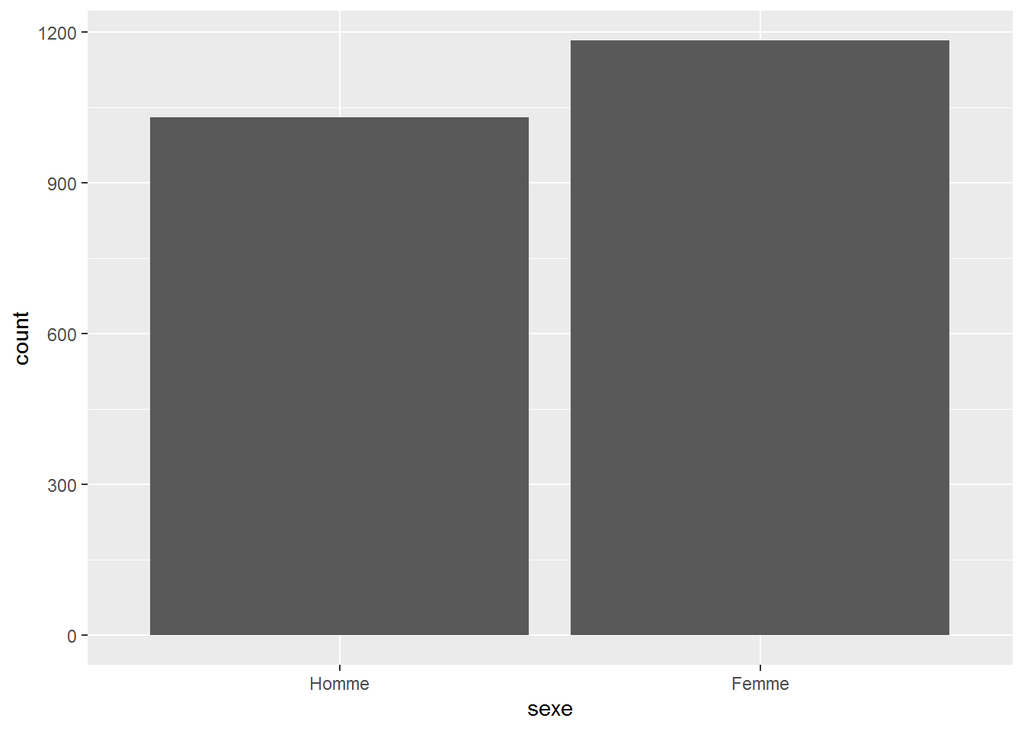

```r
# sexe
graph_sexe_nopond <- ggplot(df_barometre_2018, aes(x = sexe)) +
  geom_bar()

graph_sexe_nopond
```

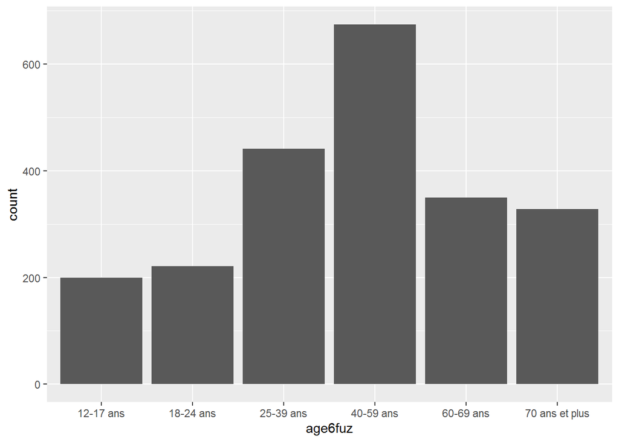

```r
# age
ggplot(df_barometre_2018, aes(x = age6fuz)) +
  geom_bar()
```

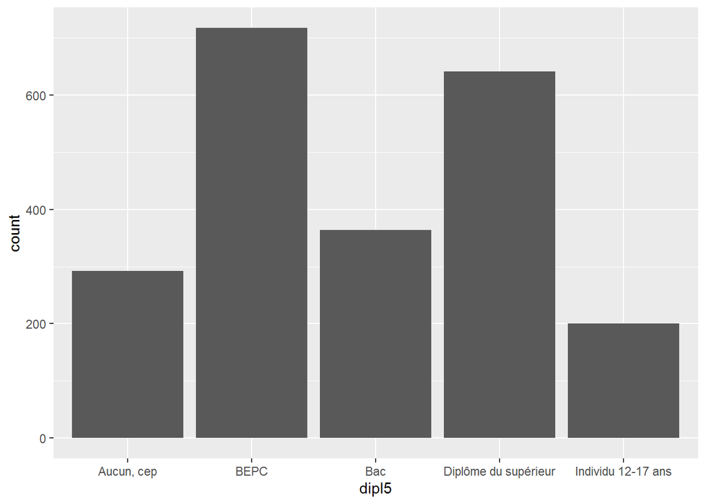

```r
# diplome
ggplot(df_barometre_2018, aes(x = dipl5)) +
  geom_bar()
```

- Faire de même en utilisant les poids. Observer les différences.

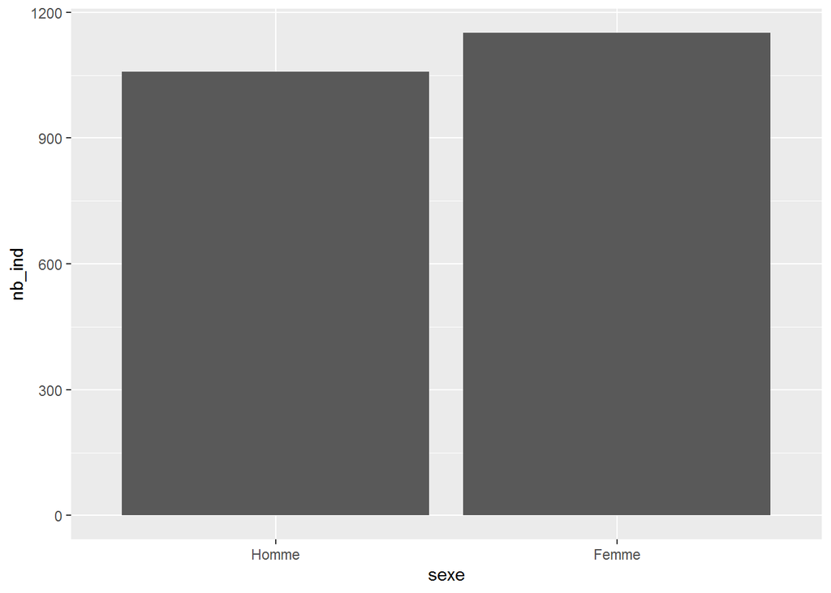

```r
# sexe
graph_sexe_pond <- df_barometre_2018 %>%
  group_by(sexe) %>%
  summarise(nb_ind = sum(pond)) %>%
  ggplot(aes(x = sexe, y = nb_ind)) +
  geom_bar(stat = "identity")

graph_sexe_pond
```

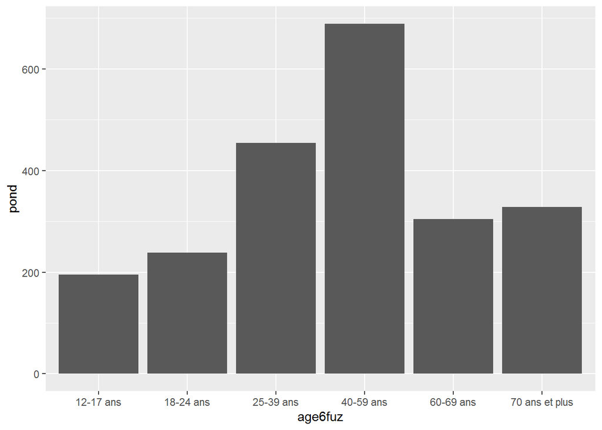

```r
# age
ggplot(df_barometre_2018, aes(x = age6fuz, y = pond)) +
  geom_col()
```

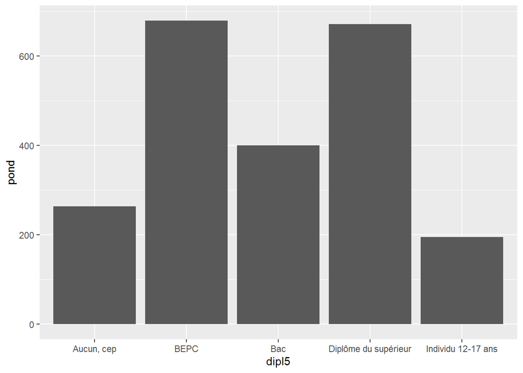

```r
# diplome
ggplot(df_barometre_2018, aes(x = dipl5, y = pond)) +
  geom_bar(stat = "identity")
```

- Comment peut-on représenter les deux ensemble ?
  - Solution 1 : Utiliser les groupes

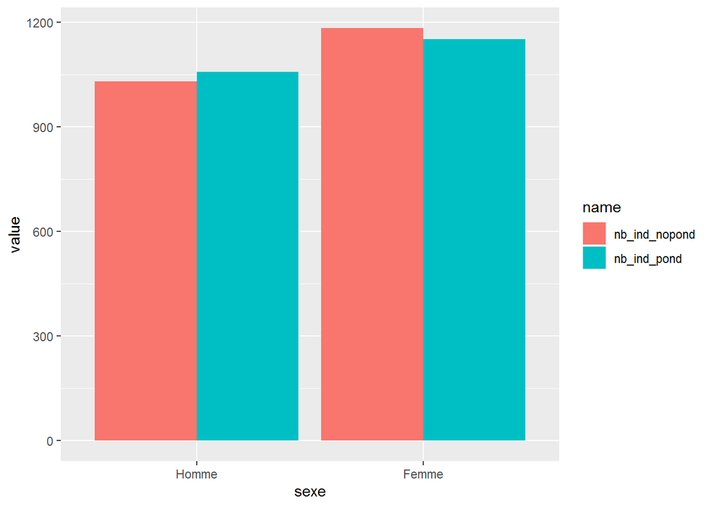

```r
df_sexe_2018 <- df_barometre_2018 %>%
  group_by(sexe) %>%
  summarise(nb_ind_pond = sum(pond),
            nb_ind_nopond = n()) %>%
  pivot_longer(-sexe)

df_sexe_2018 %>%
  ggplot(aes(x = sexe, y = value, fill = name)) +
  geom_bar(stat = "identity", position = "dodge")
```

- Solution 2 : avec des facettes

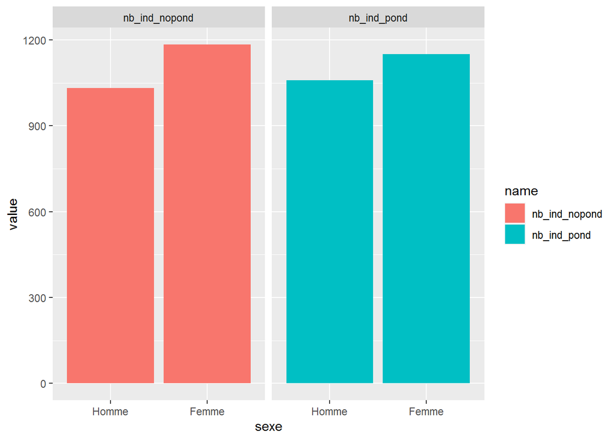

```r
df_sexe_2018 %>%
  ggplot(aes(x = sexe, y = value, fill = name)) +
  geom_bar(stat = "identity") +
  facet_wrap(vars(name))
```

- Solution 3 : avec `patchwork` : https://patchwork.data-imaginist.com/

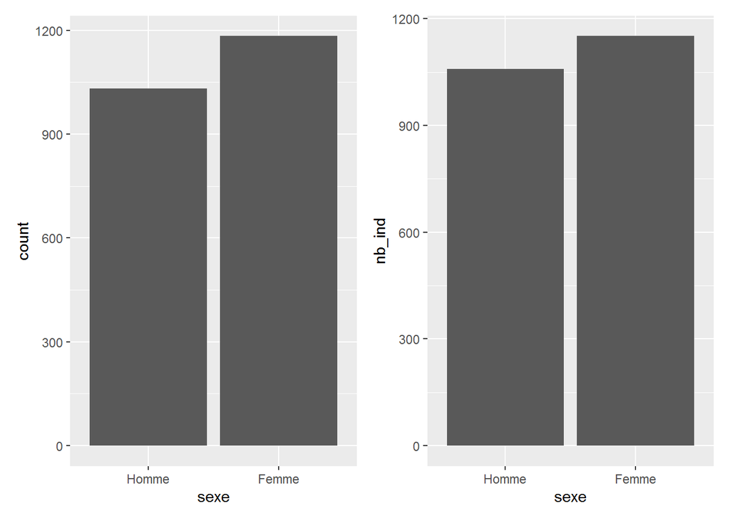

```r
graph_sexe_nopond + graph_sexe_pond
```

### Principaux freins à l’utilisation d’internet

On va se concentrer sur cette variable, en fonction du sexe. On pondère à chaque fois.

- Représenter le diagramme en barre simple de la variable `freinweb` ;

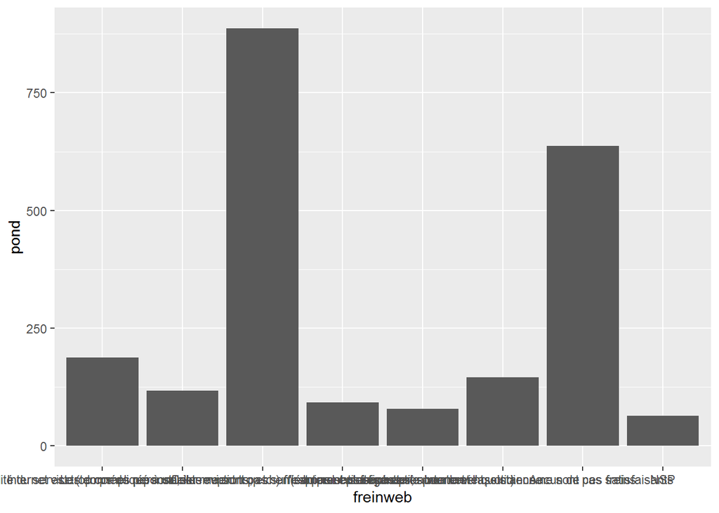

```r
df_barometre_2018 %>%
  ggplot(aes(x = freinweb, y = pond)) +
  geom_col()
```

- Gérer les axes et la légende (réordonner ?);

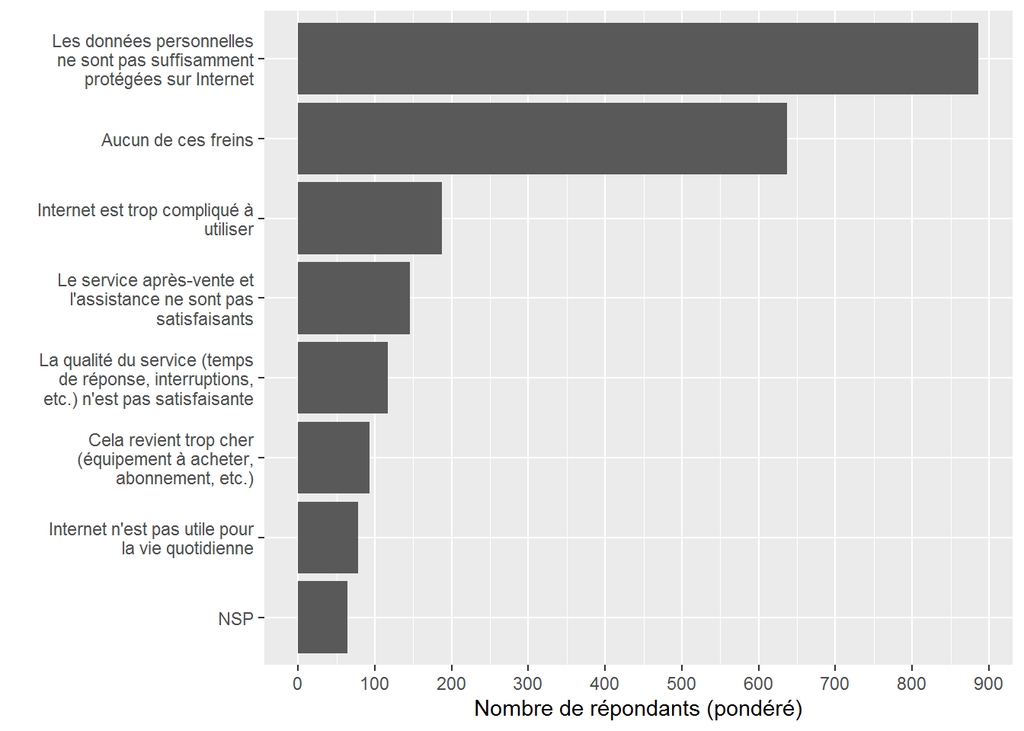

```r
df_barometre_2018 %>%
  group_by(freinweb) %>%
  summarise(nb_ind = sum(pond)) %>%
  ungroup() %>%
  mutate(freinweb = fct_reorder(freinweb, nb_ind)) %>%
  ggplot(aes(x = freinweb, y = nb_ind)) +
  geom_col() +
  coord_flip() +
  scale_x_discrete(
    name = "",
    labels = function(x) {
      str_wrap(x, 30)
    }
  ) +
  scale_y_continuous(name = "Nombre de répondants (pondéré)", breaks = seq(0, 1000, 100))
```

- Gérer les couleurs pour avoir quelque chose d’harmonieux ;

```r
graph_freinweb <- df_barometre_2018 %>%
  group_by(freinweb) %>%
  summarise(nb_ind = sum(pond)) %>%
  ungroup() %>%
  mutate(freinweb = fct_reorder(freinweb, nb_ind)) %>%
  ggplot(aes(x = freinweb, y = nb_ind)) +
  geom_col(fill = "#ff6961", color = "black") +
  coord_flip() +
  scale_x_discrete(
    name = "",
    labels = function(x) {
      str_wrap(x, 30)
    }
  ) +
  scale_y_continuous(name = "Nombre de répondants (pondéré)", breaks = seq(0, 1000, 100))
```

- Gérer le thème pour simplifier ;

```r
graph_freinweb <- graph_freinweb +
  theme_minimal(base_line_size = 1.1) +
  theme(panel.grid.minor = element_blank(),
        panel.grid.major.y = element_blank(),
        axis.text = element_text(face = "bold", color = "black"),
        plot.title = element_text(face = "bold", color = "black"),
        plot.title.position = "plot")
```

- Ajouter un titre et une légence ;

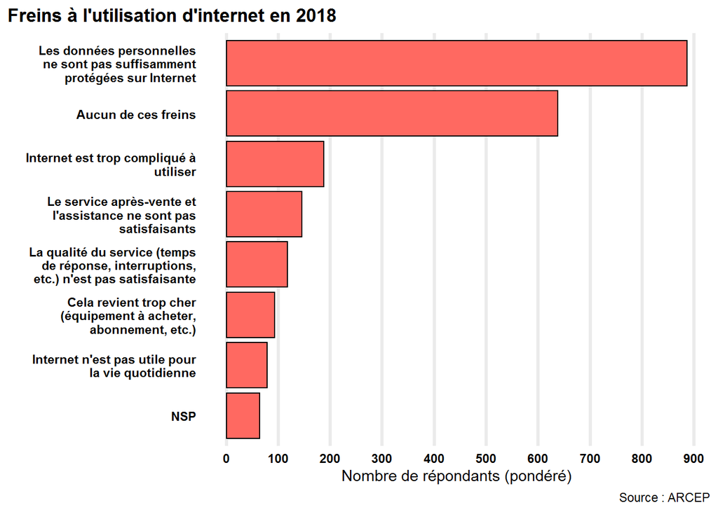

```r
graph_freinweb +
  labs(title = "Freins à l'utilisation d'internet en 2018",
       caption = "Source : ARCEP")
```

- Exporter le graphique en local avec une bonne résolution.

```r
ggsave("freinweb.png", dpi = 400, height = 200, width = 250, units = "mm")
```

- On peut aussi vouloir faire la répartition de ces motifs par niveau de diplôme.

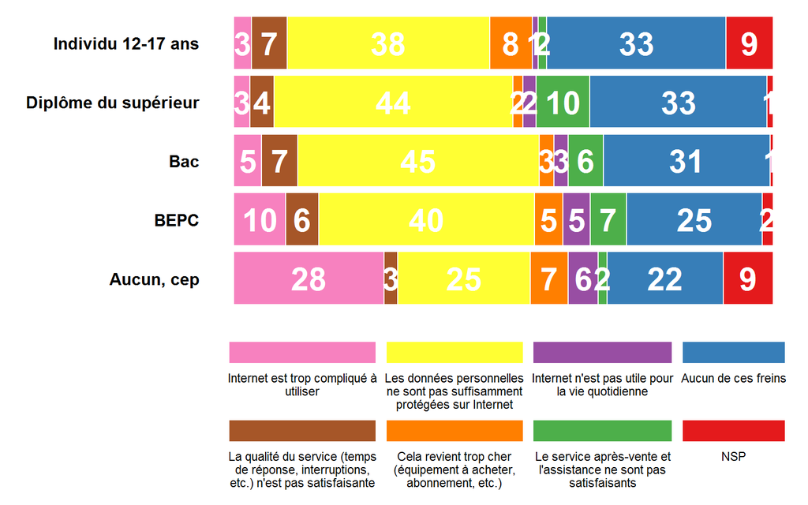

```r
df_barometre_2018 %>%
  group_by(freinweb, dipl5) %>%
  summarise(nb_ind = sum(pond)) %>%
  group_by(dipl5) %>%
  mutate(part_ind = nb_ind / sum(nb_ind) * 100) %>%
  ungroup() %>%
  ggplot(aes(x = dipl5, y = part_ind, fill = fct_rev(freinweb))) +
  geom_col(color = "white") +
  geom_text(
    aes(label = round(part_ind, 0)),
    position = position_stack(vjust = 0.5),
    size = 8,
    color = "#ffffff",
    fontface = "bold"
  ) +
  scale_x_discrete(name = "") +
  scale_fill_brewer(name = "",
                       palette = "Set1", labels = function(x){str_wrap(x, 30)},
                       guide = guide_legend(label.position = "bottom", reverse = TRUE)) +
  coord_flip() +
  theme_minimal() +
  theme(
    panel.grid.minor = element_blank(),
    panel.grid.major = element_blank(),
    axis.text = element_text(face = "bold", color = "black"),
    plot.title = element_text(face = "bold", color = "black"),
    plot.title.position = "plot",
    axis.text.x = element_blank(),
    axis.title.x = element_blank(),
    axis.text.y = element_text(size = 12, color = "black", face = "bold"),
    legend.position = "bottom"
  )
```

### Nombre d’heures

- Comment se répartissent le nombre d’heures d’utilisation du web et de la télé ?
  - en histogramme ;

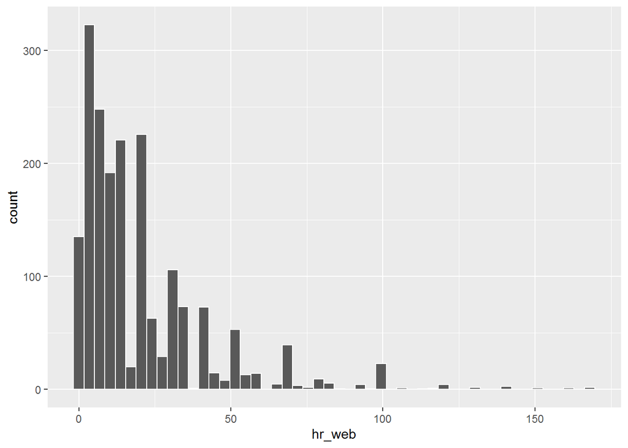

```r
df_barometre_2018 %>%
  filter(hr_web < 500) %>%
  ggplot(aes(x = hr_web, weight = pond)) +
  geom_histogram(color = "white", bins = 50)
```

- en boxplot (ou une variante).

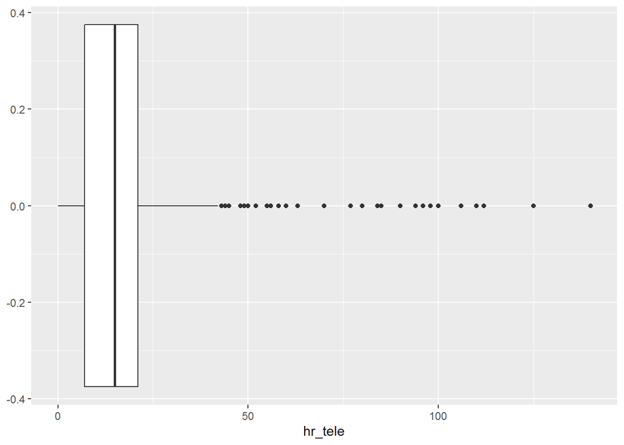

```r
df_barometre_2018 %>%
  filter(hr_tele < 500) %>%
  ggplot(aes(x = hr_tele, weight = pond)) +
  geom_boxplot()
```

- Quelle est la relation des deux ?
  - Faire un nuage de point ;

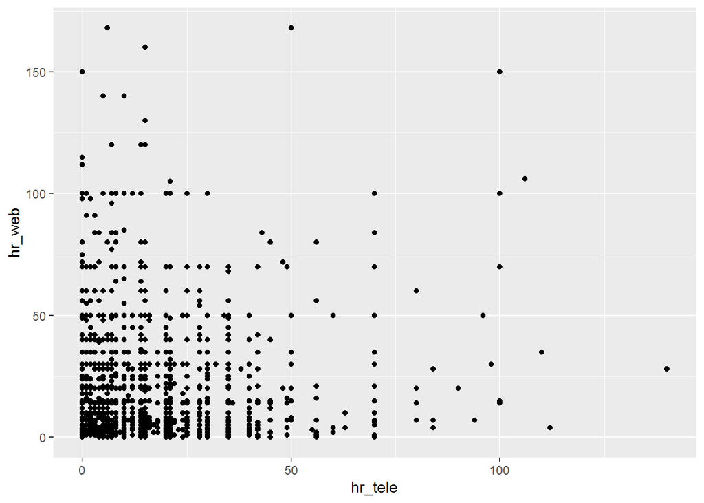

```r
df_barometre_2018 %>%
  filter(hr_tele < 500 & hr_web < 500) %>%
  ggplot(aes(x = hr_tele, y = hr_web)) +
  geom_point()
```

- Y ajouter la tendance linéaire ;

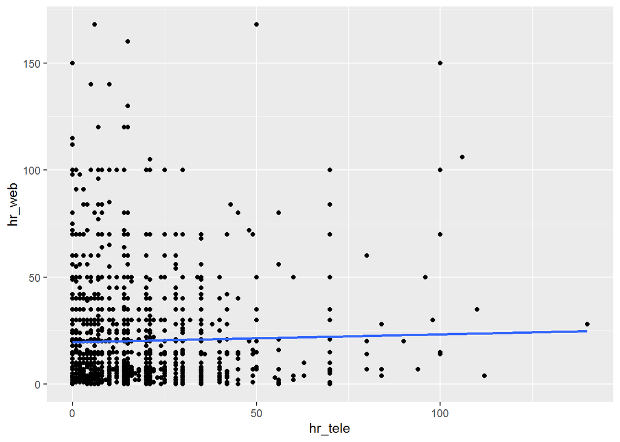

```r
df_barometre_2018 %>%
  filter(hr_tele < 500 & hr_web < 500) %>%
  ggplot(aes(x = hr_tele, y = hr_web)) +
  geom_point() +
  geom_smooth(formula = "y ~ x", method = "lm", se = FALSE)
```

- Est-ce lisible ? Si non, trouver des solutions :
  - Densité / `alpha` ;

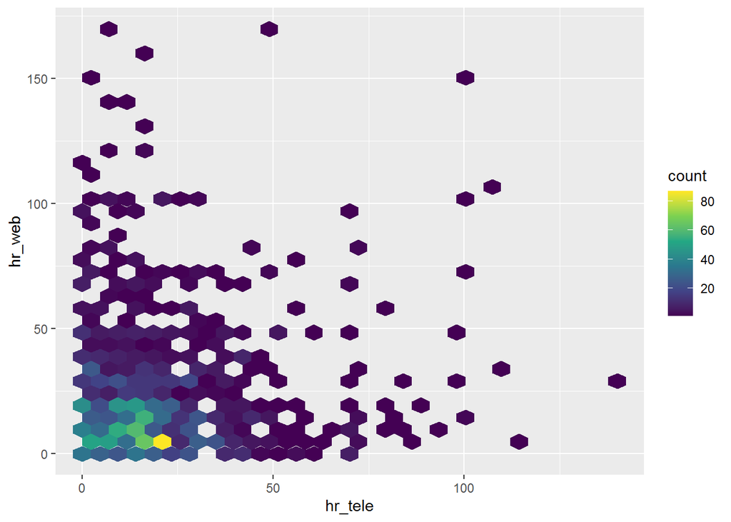

```r
# densité
df_barometre_2018 %>%
  filter(hr_tele < 500 & hr_web < 500) %>%
  ggplot(aes(x = hr_tele, y = hr_web)) +
  geom_hex(bins = 30) +
  scale_fill_viridis_c()
```

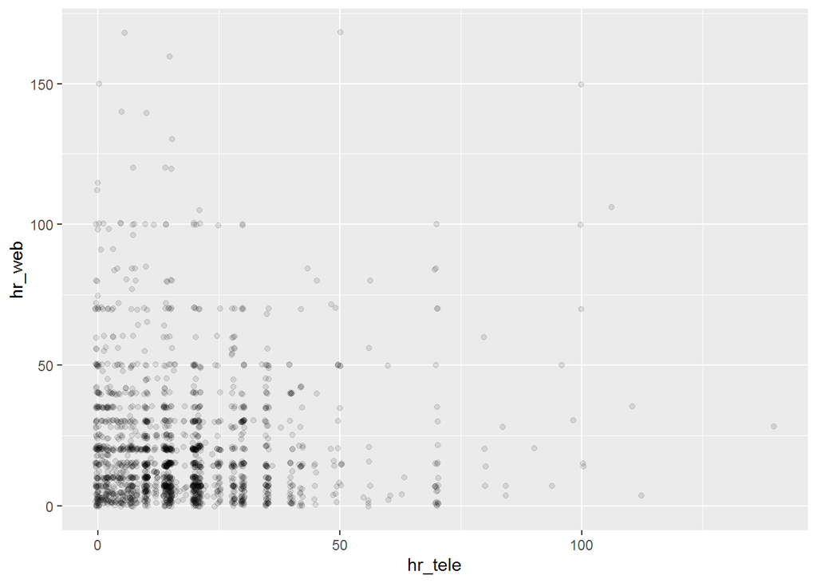

```r
# alpha
df_barometre_2018 %>%
  filter(hr_tele < 500 & hr_web < 500) %>%
  ggplot(aes(x = hr_tele, y = hr_web)) +
  geom_jitter(alpha = 0.1)
```

- Distinguer les classes d’âge :
  - Avec des groupes (`ggforce` par exemple) ;

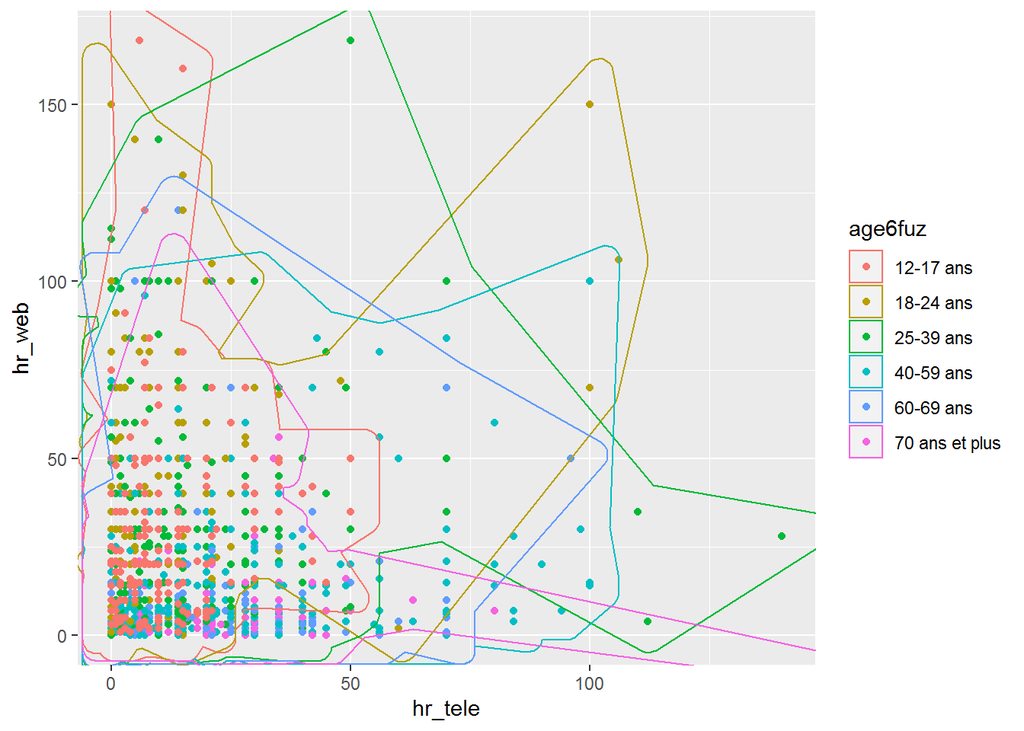

```
+ Avec des facettes.
```

```r
df_barometre_2018 %>%
  filter(hr_tele < 500 & hr_web < 500) %>%
  ggplot(aes(x = hr_tele, y = hr_web, color = age6fuz)) +
  geom_point() +
  geom_mark_hull()
```

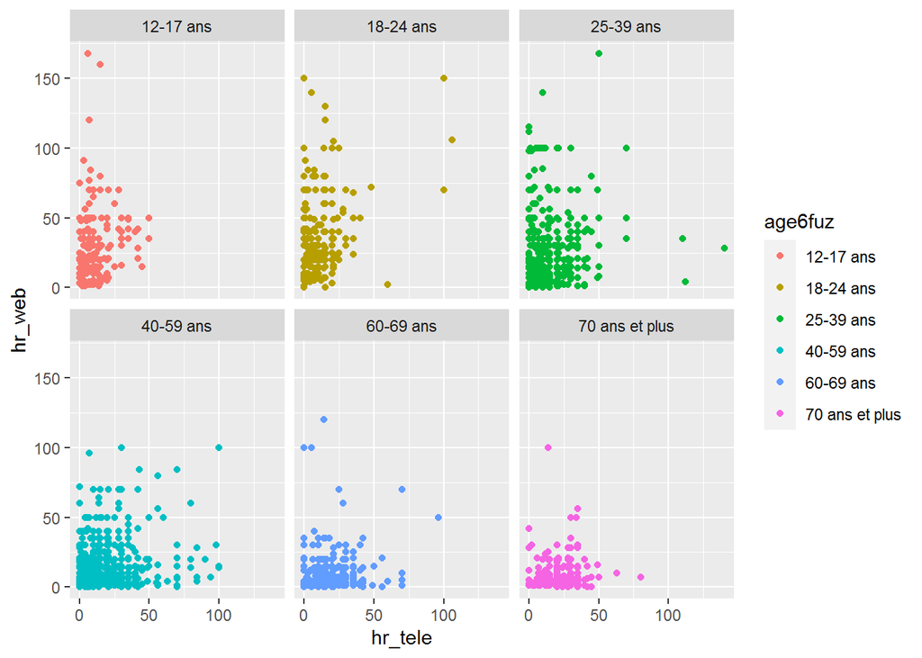

```r
df_barometre_2018 %>%
  filter(hr_tele < 500 & hr_web < 500) %>%
  ggplot(aes(x = hr_tele, y = hr_web, color = age6fuz)) +
  geom_point() +
  facet_wrap(vars(age6fuz))
```

- Faire une échelle en log.

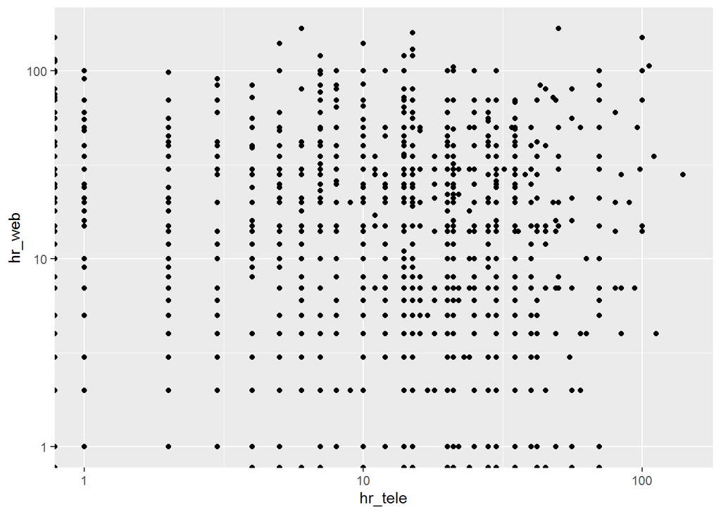

```r
df_barometre_2018 %>%
  filter(hr_tele < 500 & hr_web < 500) %>%
  ggplot(aes(x = hr_tele, y = hr_web)) +
  geom_point() +
  scale_x_log10() +
  scale_y_log10()
```

- Ajuster échelles, thème et couleur.

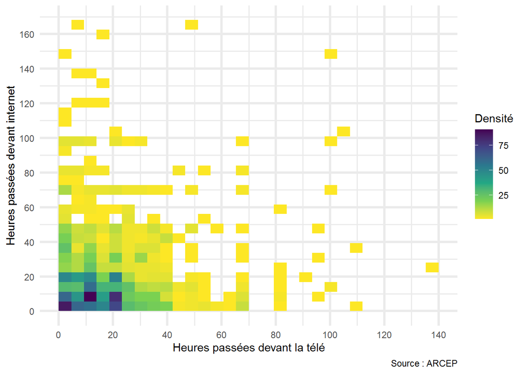

```r
df_barometre_2018 %>%
  filter(hr_tele < 500 & hr_web < 500) %>%
  ggplot(aes(x = hr_tele, y = hr_web)) +
  geom_bin2d(bins = 30) +
  scale_x_continuous(name = "Heures passées devant la télé",
                     breaks = seq(0, 160, 20)) +
  scale_y_continuous(name = "Heures passées devant internet",
                     breaks = seq(0, 160, 20)) +
  scale_fill_viridis_c(name = "Densité", direction = -1) +
  theme_minimal(base_line_size = 1.1) +
  labs(caption = "Source : ARCEP")
```

## Analyse longitudinale

On va maintenant analyser l’évolution des variables sur quelques années.

### Traitement

- Calculer la part de ceux ayant internet par an, ainsi que pour le téléphone fixe.

```r
df_barometre_long_internet <- df_barometre_ok %>%
  group_by(annee, internet) %>%
  summarise(nb_ind = sum(pond)) %>%
  group_by(annee) %>%
  mutate(part_internet = nb_ind /sum(nb_ind) * 100) %>%
  ungroup() %>%
  filter(internet == "Oui") %>%
  select(annee, part_internet)

df_barometre_long_telfixe <- df_barometre_ok %>%
  group_by(annee, telfixe) %>%
  summarise(nb_ind = sum(pond)) %>%
  group_by(annee) %>%
  mutate(part_telfixe = nb_ind /sum(nb_ind) * 100) %>%
  ungroup() %>%
  filter(telfixe == "Oui") %>%
  select(annee, part_telfixe)

df_barometre_long <- df_barometre_long_internet %>%
  full_join(df_barometre_long_telfixe, by = "annee")
```

### Série

- Répresenter les deux séries séparement, avec une échelle de 0 à 100 ;

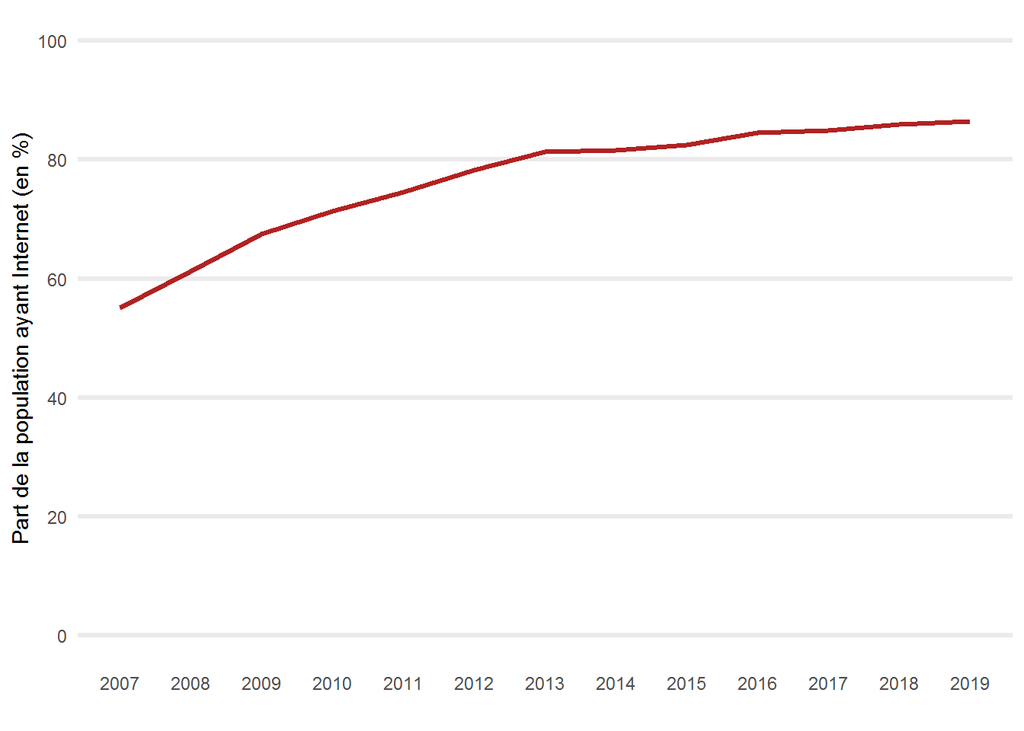

```r
df_barometre_long %>%
  ggplot(aes(x = annee, y = part_internet)) +
  geom_line(size = 1.1, color = "firebrick") +
  scale_x_continuous(name = "", breaks = seq(2007, 2019, 1)) +
  scale_y_continuous(name = "Part de la population ayant Internet (en %)",
                     limits = c(0, 100),
                     breaks = seq(0, 100, 20)) +
  theme_minimal(base_line_size = 1.1) +
  theme(panel.grid.major.x = element_blank(),
        panel.grid.minor = element_blank())
```

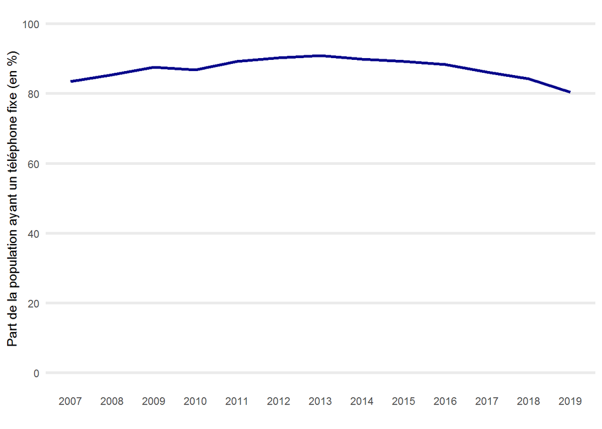

```r
df_barometre_long %>%
  ggplot(aes(x = annee, y = part_telfixe)) +
  geom_line(size = 1.1, color = "darkblue") +
  scale_x_continuous(name = "", breaks = seq(2007, 2019, 1)) +
  scale_y_continuous(name = "Part de la population ayant un téléphone fixe (en %)",
                     limits = c(0, 100),
                     breaks = seq(0, 100, 20)) +
  theme_minimal(base_line_size = 1.1) +
  theme(panel.grid.major.x = element_blank(),
        panel.grid.minor = element_blank())
```

- Puis ensemble.

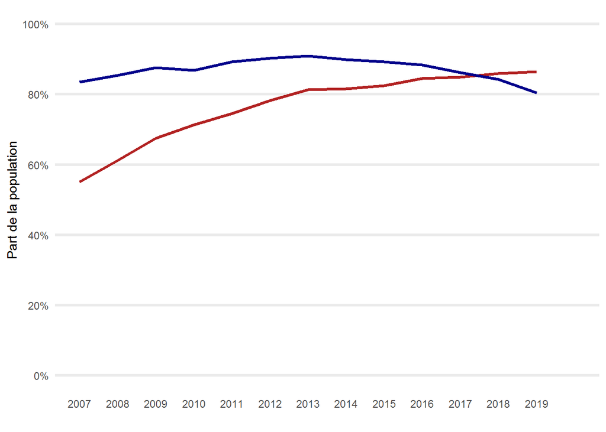

```r
graph_part_evol <- df_barometre_long %>%
  pivot_longer(-annee, names_to = "type_part", values_to = "val") %>%
  mutate(lab_part = fct_recode(type_part,
                               "Internet" = "part_internet",
                               "Tel. fixe" = "part_telfixe")) %>%
  ggplot(aes(x = annee, y = val, color = type_part)) +
  geom_line(size = 1.1) +
  scale_x_continuous(name = "", breaks = seq(2007, 2019, 1), limits = c(2007, 2020)) +
  scale_y_continuous(
    name = "Part de la population",
    limits = c(0, 100),
    breaks = seq(0, 100, 20),
    labels = function(x) {
      paste0(x, "%")
    }
  ) +
  scale_color_manual(values = c("part_internet" = "firebrick",
                                "part_telfixe" = "darkblue")) +
  guides(color = FALSE) +
  theme_minimal(base_line_size = 1.1) +
  theme(panel.grid.major.x = element_blank(),
        panel.grid.minor = element_blank())

graph_part_evol
```

- Afficher le nom de séries :
  - Dans le titre avec `ggtext` -> cela ne devrait pas marcher chez vous car le package n’est pas encore sur le CRAN ;

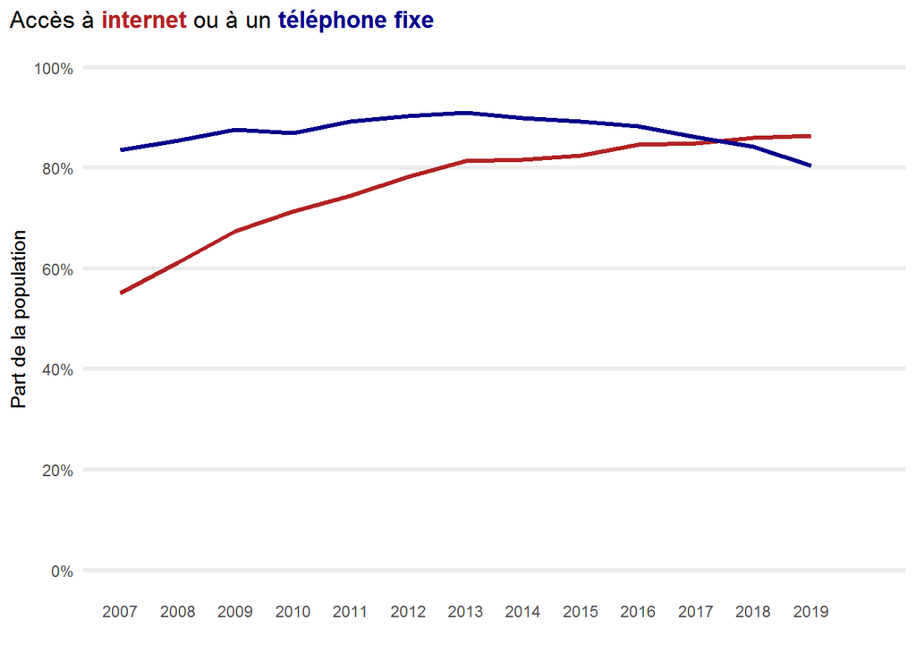

```r
library(ggtext)

graph_part_evol +
  labs(
    title = "Accès à <b style = 'color:firebrick;;'>internet</b> ou à un <b style = 'color:darkblue;'>téléphone fixe</b>"
  ) +
  theme(plot.title = element_markdown(),
        plot.title.position = "plot",)
```

- Dans la légende

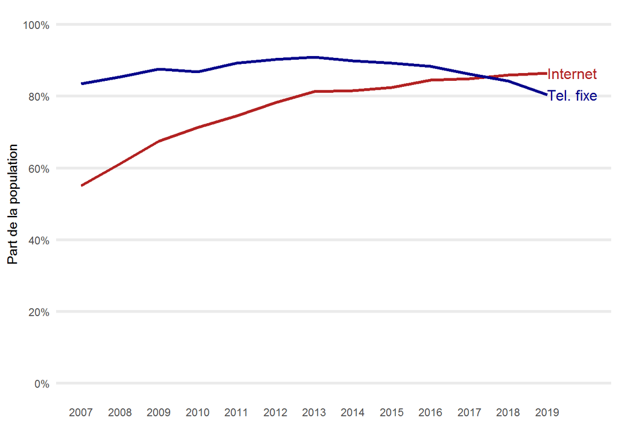

```r
library(directlabels)

graph_part_evol +
  geom_dl(aes(label = lab_part), method = "last.points")
```

### Nombre d’heures passé sur internet

- Faire un `boxplot` par année du nombre d’heures passés sur internet ;

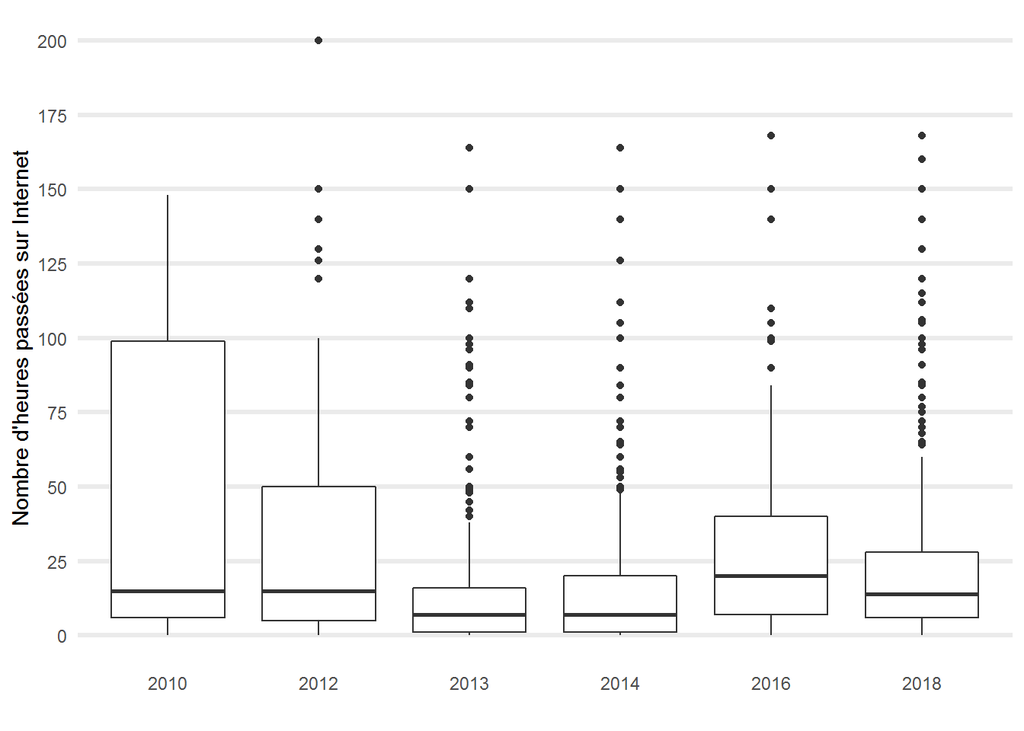

```r
df_barometre_ok %>%
  filter(!is.na(hr_web) & hr_web < 500) %>%
  ggplot(aes(x = as.character(annee), y = hr_web, weight = pond)) +
  geom_boxplot() +
  scale_x_discrete(name = "") +
  scale_y_continuous(name = "Nombre d'heures passées sur Internet", breaks = seq(0, 200, 25)) +
  theme_minimal(base_line_size = 1.1) +
  theme(panel.grid.major.x = element_blank(),
        panel.grid.minor = element_blank())
```

- Idem mais par tranch d’âge ;

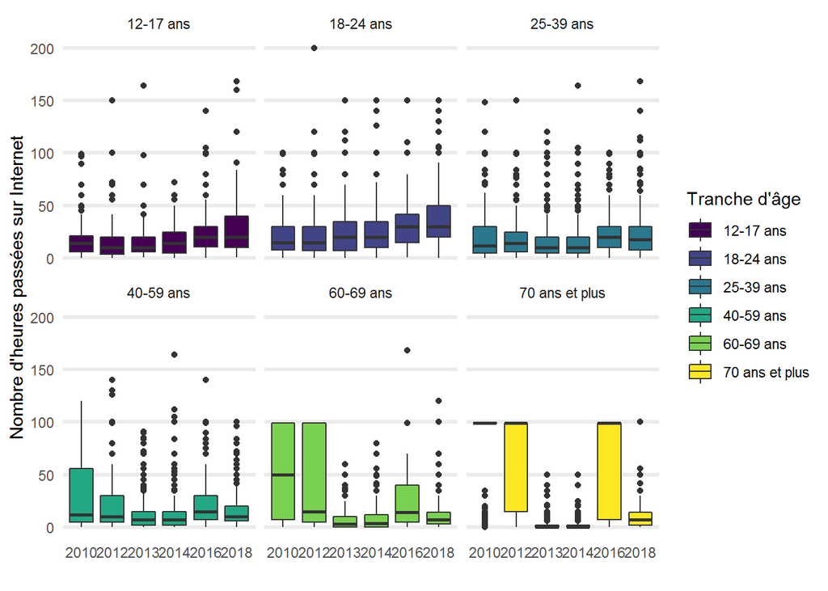

```r
df_barometre_ok %>%
  filter(!is.na(hr_web) & hr_web < 500) %>%
  ggplot(aes(x = as.character(annee), y = hr_web, weight = pond, fill = age6fuz)) +
  geom_boxplot() +
  scale_x_discrete(name = "") +
  scale_y_continuous(name = "Nombre d'heures passées sur Internet", breaks = seq(0, 200, 50)) +
  scale_fill_viridis_d(name = "Tranche d'âge") +
  facet_wrap(vars(age6fuz), ncol = 3) +
  theme_minimal(base_line_size = 1.1) +
  theme(panel.grid.major.x = element_blank(),
        panel.grid.minor = element_blank())
```

# Pour poursuivre

## Annotations

Une option de plus est les annotations qui permettent d’ajouter du texte directement sur le graphique pour le travailler davantage : https://ggplot2.tidyverse.org/reference/annotate.html

## Thème

Vous pouvez personnaliser votre thème et votre palette de couleur selon votre organisation. Voir par exemple ce qu’à fait la BBC : https://bbc.github.io/rcookbook/

L’aspect de vos sorties est un enjeu organisationnel. Le design de vos graphiques est important pour véhiculer le bon message.

Une seule règle : faites minimalistes.

Deux ressources :

- https://ggplot2.tidyverse.org/reference/theme.html ;
- https://ggplot2.tidyverse.org/reference/guide_legend.html.

La personnalisation peut être poussée très loin.

## Extensions

De nombreuses extensions de `ggplot2` existent :

- `gghighlight` pour mettre en valeur des données : https://cran.r-project.org/web/packages/gghighlight/vignettes/gghighlight.html ;
- `gganimate` pour réaliser des graphiques animés : https://gganimate.com/articles/gganimate.html
- `ggtext`: https://github.com/wilkelab/ggtext ;
- Et d’autres : http://exts.ggplot2.tidyverse.org/ .

## Graphiques interactifs

D’autres façons de réaliser des graphiques existent, notamment avec plus d’interactivité. Un exemple est `plotly` et la fonction `ggplotly()` qui transcrit (imparfaitement) depuis `ggplot2`

- https://plotly.com/r/
- https://plotly.com/ggplot2/extending-ggplotly/